# **Panorama da inflação**

Os principais índices de inflação do Brasil, apontam em agosto de 2002 um avanço da inflação de em média **1.28%**. Com esse resultado, no ano a inflação acumula uma variação média positiva de **5.97%**, e em 12 meses uma variação média acumulada de **9.21%**.

[output not shown]

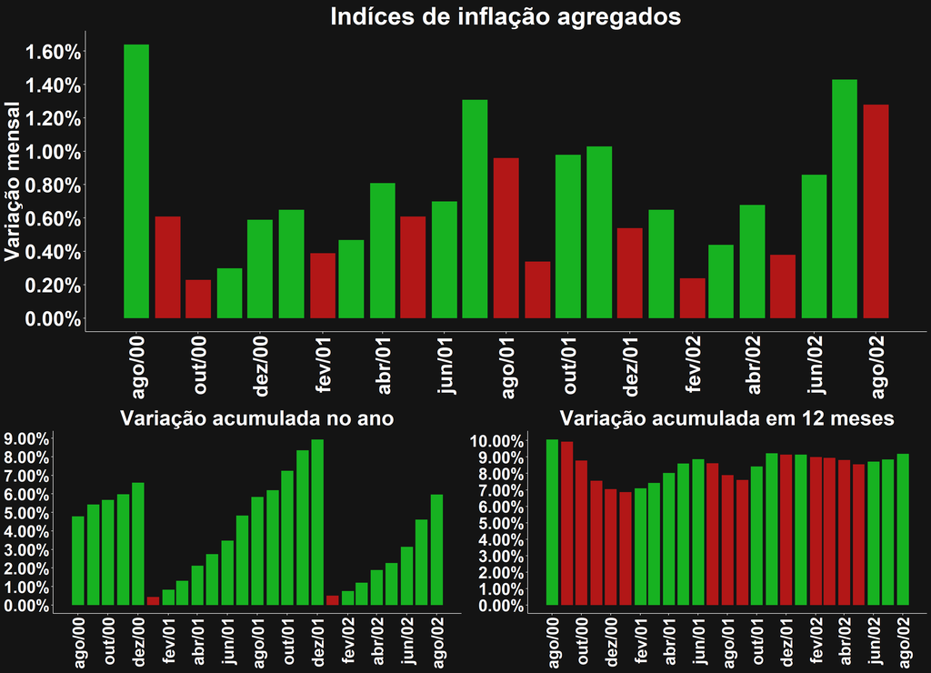

Índices selecionados para a média: IPCA, INPC e IGP-M.

# IPCA

|  | 08/2001 | 07/2002 | 08/2002 |
| --- | --- | --- | --- |
| Variação mensal | 0.7% | 1.19% | 0.65% |
| Variação acumulada no ano | 5.06% | 4.17% | 4.85% |
| Variação acumulada em 12 meses | 6.41% | 7.51% | 7.46% |

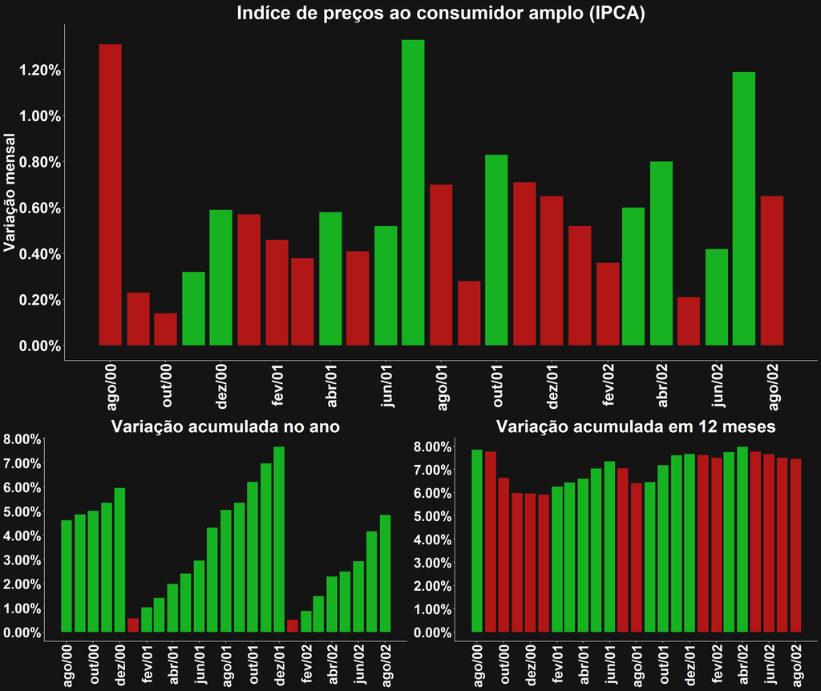

|  | Variação mensal | Variação acumulada no ano | Peso mensal |
| --- | --- | --- | --- |
| Alimentação e bebidas | 1.94% | 3.63% | 21.86% |
| Habitação | 0.43% | 9.3% | 16.76% |
| Artigos de residência | 0.66% | 3.36% | 5.62% |
| Vestuário | 0.21% | 4.91% | 5.4% |
| Transportes | -0.15% | 2.09% | 21.67% |
| Saúde e cuidados pessoais | 0.5% | 4.98% | 10.66% |
| Despesas pessoais | 0.53% | 3.81% | 9.41% |
| Educação | 0.29% | 7.31% | 4.91% |
| Comunicação | 0.47% | 11.01% | 3.7% |

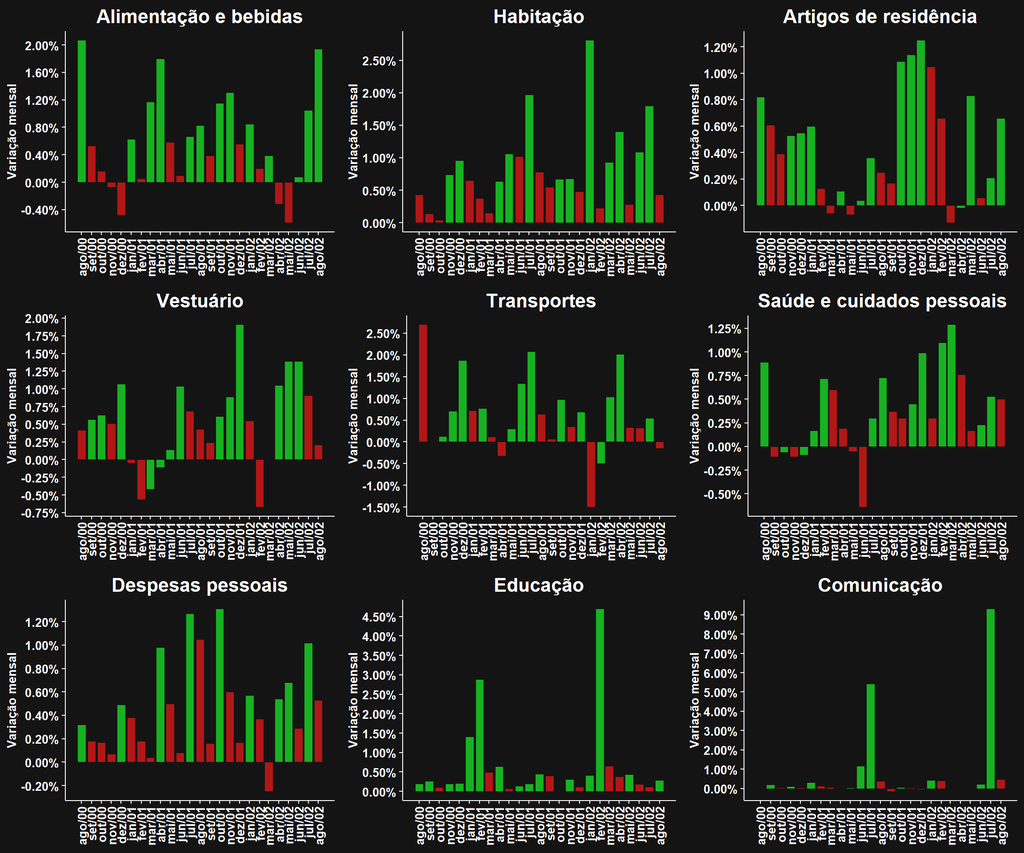

A nível de sub-itens os que mais influenciaram positivamente no resultado em relação ao seu peso foram Pão francês (9.7%%) e Energia elétrica residencial (1.11%%), e negativamente Gasolina (-1.39%%) e Gás de botijão (-3.11%%).

|  | Variação mensal | Variação acumulada no ano | Peso mensal |
| --- | --- | --- | --- |
| Pão francês | 9.7% | 15.62% | 1.42% |
| Passagem aérea | 7.09% | 23.59% | 0.51% |
| Taxa de água e esgoto | 2.18% | 6.51% | 1.65% |
| Energia elétrica residencial | 1.11% | 16.17% | 4.27% |

|  | Variação mensal | Variação acumulada no ano | Peso mensal |
| --- | --- | --- | --- |
| Automóvel novo | -0.36% | -1.31% | 3.26% |
| Gasolina | -1.39% | -1.6% | 4.2% |
| Gás de botijão | -3.11% | 33.97% | 1.77% |
| Etanol | -4.48% | -12.7% | 0.88% |

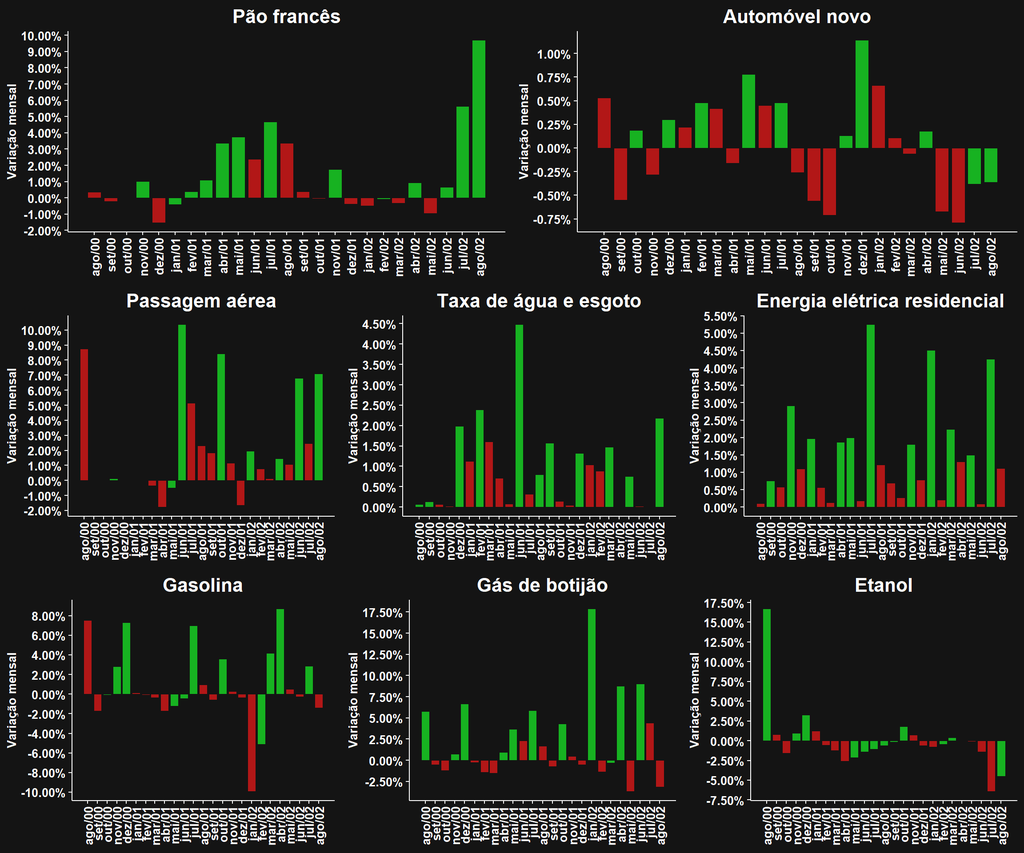

# INPC

O Indíce Nacional de Preços ao Consumidor (INPC) variou 0.86% em agosto, valor superior ao mesmo período do ano anterior quando apresentou uma taxa de 0.79%. Com esse resultado o indíce acumula no ano uma variação positiva de 5.51%, e em 12 meses uma variação positiva de 9.16%.

|  | 08/2001 | 07/2002 | 08/2002 |
| --- | --- | --- | --- |
| Variação mensal | 0.79% | 1.15% | 0.86% |
| Variação acumulada no ano | 5.79% | 4.61% | 5.51% |
| Variação acumulada em 12 meses | 7.31% | 9.08% | 9.16% |

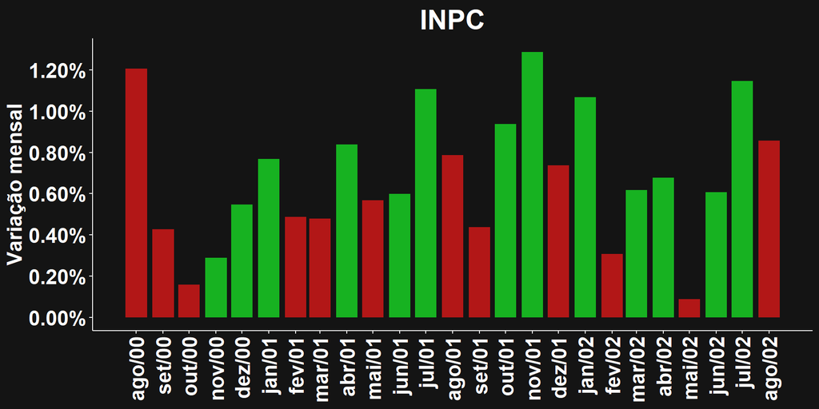

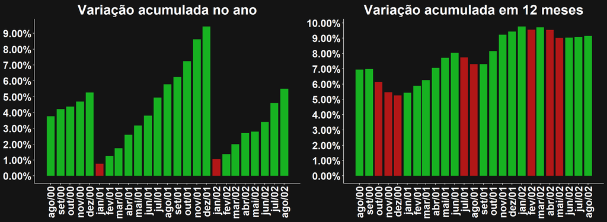

# IGP-M

O Indíce Geral de Preços de Mercado (IGP-M) variou 2.32% em agosto, valor superior ao mesmo período do ano anterior quando apresentou uma taxa de 1.38%. Com esse resultado o indíce acumula no ano uma variação positiva de 7.56%, e em 12 meses uma variação positiva de 11.01%.

|  | 08/2001 | 07/2002 | 08/2002 |
| --- | --- | --- | --- |
| Variação mensal | 1.38% | 1.95% | 2.32% |
| Variação acumulada no ano | 6.68% | 5.12% | 7.56% |
| Variação acumulada em 12 meses | 10.01% | 9.99% | 11.01% |

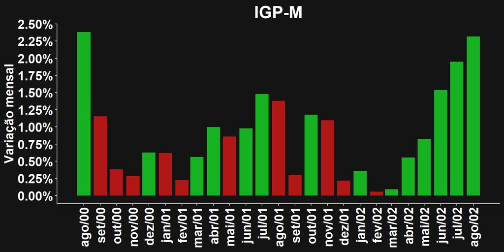

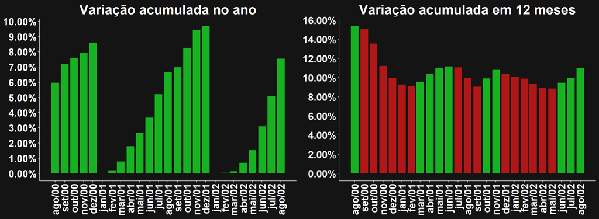

# IGP-DI

O Indíce Geral de Preços - Disponibilidade Interna (IGP-DI) variou 2.36% em agosto, valor superior ao mesmo período do ano anterior quando apresentou uma taxa de 0.9%. Com esse resultado o indíce acumula no ano uma variação positiva de 8.52%, e em 12 meses uma variação positiva de 11.76%.

|  | 08/2001 | 07/2002 | 08/2002 |
| --- | --- | --- | --- |
| Variação mensal | 0.9% | 2.05% | 2.36% |
| Variação acumulada no ano | 6.87% | 6.02% | 8.52% |
| Variação acumulada em 12 meses | 9.79% | 10.17% | 11.76% |

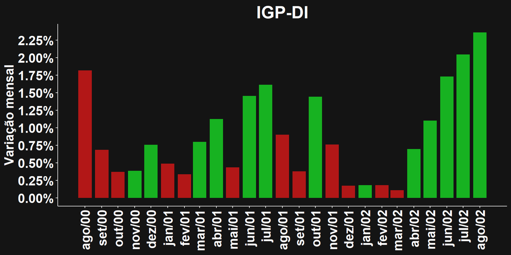

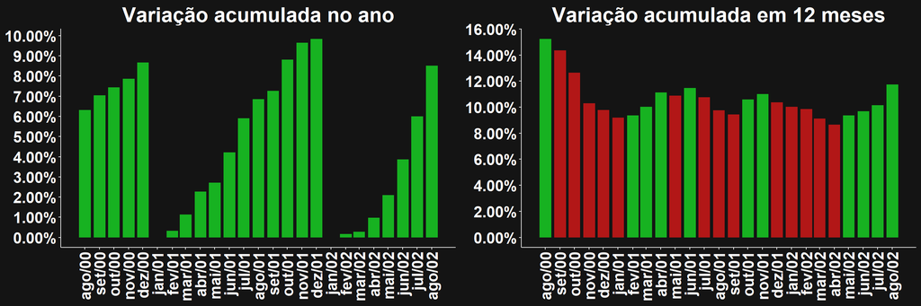

[output not shown]

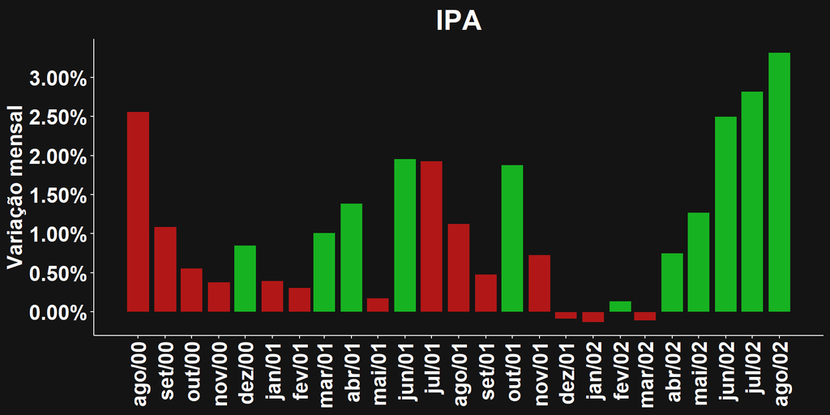

[figure not shown]

O Indíce de Preços ao Consumidor (IPC), integrante do IGP-DI com peso de 30%, apresentou variação de 0.76% em agosto, valor superior ao mesmo período do ano anterior quando apresentou uma taxa de 0.54%. Com esse resultado o indíce acumula no ano uma variação positiva de 3.96%, e em 12 meses uma variação positiva de 7.31%.

|  | 08/2001 | 07/2002 | 08/2002 |
| --- | --- | --- | --- |
| Variação mensal | 0.54% | 1.03% | 0.76% |
| Variação acumulada no ano | 4.73% | 3.17% | 3.96% |
| Variação acumulada em 12 meses | 6.54% | 7.07% | 7.31% |

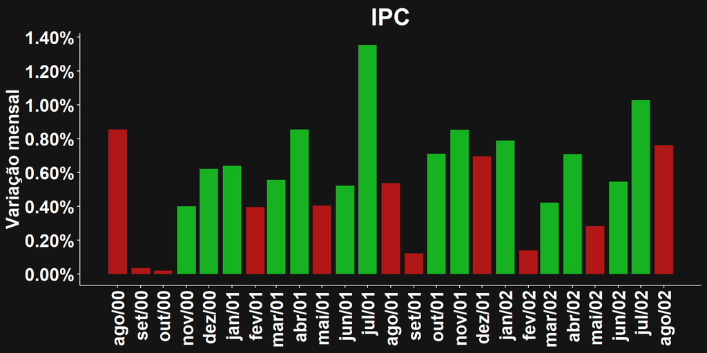

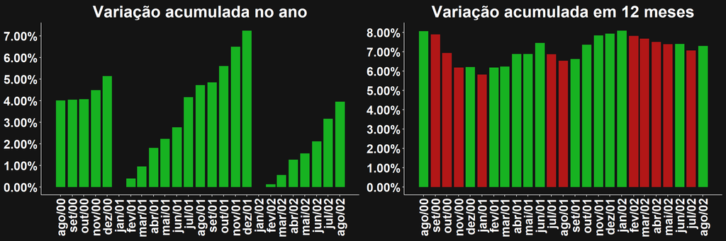

O Indíce Nacional de Custos de Construção (INCC), integrante do IGP-DI com peso de 10%, apresentou variação de 1% em agosto, valor superior ao mesmo período do ano anterior quando apresentou uma taxa de 0.62%. Com esse resultado o indíce acumula no ano uma variação positiva de 5.98%, e em 12 meses uma variação positiva de 9.11%.

|  | 08/2001 | 07/2002 | 08/2002 |
| --- | --- | --- | --- |
| Variação mensal | 0.62% | 0.29% | 1% |
| Variação acumulada no ano | 5.5% | 4.93% | 5.98% |
| Variação acumulada em 12 meses | 7.87% | 8.69% | 9.11% |

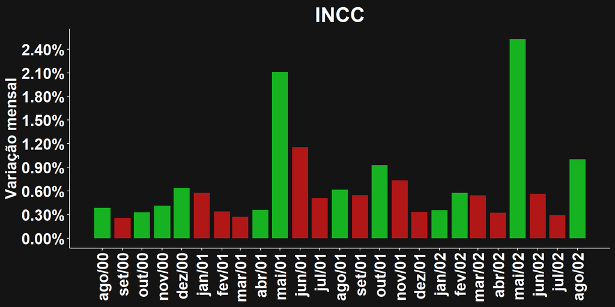

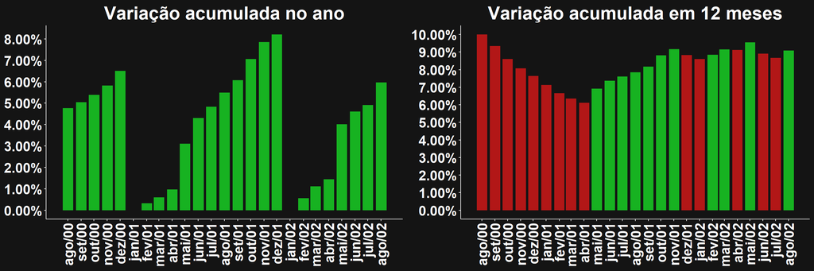

# Estatísticas

As estatísticas descritivas a seguir são feitas com base nos últimos 48 meses, e tem como objetivo possibilitar a avaliação do resultado observado em comparação aos períodos anteriores.

|  | Minimo | 1 Quartil | Mediana | Media | 3 Quartil | Maximo | Desvio Padrão |
| --- | --- | --- | --- | --- | --- | --- | --- |
| IPCA | -0.22% | 0.3% | 0.54% | 0.55% | 0.7% | 1.61% | 0.39% |
| INPC | -0.31% | 0.3% | 0.58% | 0.58% | 0.84% | 1.39% | 0.42% |
| IGP-M | -0.32% | 0.31% | 0.83% | 0.96% | 1.5% | 3.61% | 0.84% |
| IGP-DI | -0.34% | 0.3% | 0.85% | 0.98% | 1.46% | 4.44% | 0.89% |
| IPA | -0.82% | 0.18% | 1.05% | 1.26% | 1.98% | 6.99% | 1.38% |
| IPC | -0.19% | 0.24% | 0.54% | 0.56% | 0.81% | 1.91% | 0.43% |
| INCC | -0.05% | 0.36% | 0.55% | 0.65% | 0.86% | 2.53% | 0.47% |

Levando em consideração o desvio padrão de cada indíce, proporcionalmente os que mais se afastaram da média foram o IGP-M, o IGP-DI e o IPA.

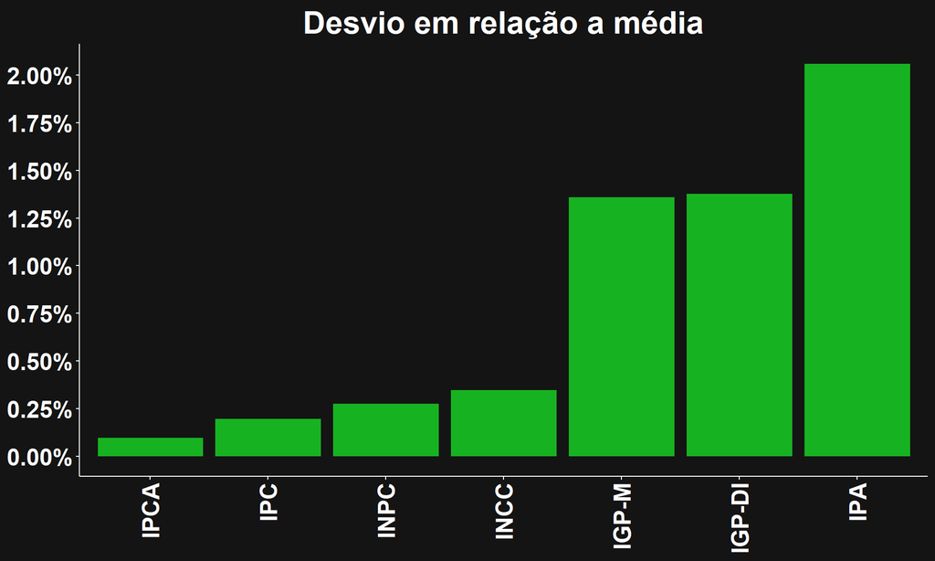

**João Victor Gomes**  
**jvg.santana@gmail.com**  
**[linkedin.com/in/jvictorgomes](https://www.linkedin.com/in/jvictorgomes/)**